# L06 Ensemble Models

Data Science 3 with R (STAT 301-3)

Louis Yang

```r
library(tidyverse)
library(tidymodels)
library(stacks)

load("model_info/stack.rda")
load("model_info/blend.rda")
load("model_info/assessment.rda")
load("model_info/wildfires_stack_trained.rda")
load("model_info/wildfires_test.rda")
```

## Overview

The main goal of this lab is to introduce and build an ensemble using `{stacks}`. Reading and reviewing `{stacks}`’s [homepage](https://stacks.tidymodels.org/index.html) and the [Getting Started with stacks vignette](https://stacks.tidymodels.org/articles/basics.html). The latter of which will be very helpful since we will be following the general workflow that is outlined in it.

## Dataset

We will be utilizing `wildfires.csv` dataset contained in the **data** subdirectory. `wildfires_codebook.html` provides a quick overview of the data which is where students should begin.

## Instructions

We want to build an ensemble model to predict the number of hectares burned by a wildfire (`burned`).

We will use all available predictors except for (`wlf`) which we used as an outcome variable in Lab 2.

We will build the ensemble model by blending nearest neighbor models, a linear regression model, and support vector machine models using radial basis function kernel.

Much of the general code has been setup for you, but there are incomplete sections where you need to add or complete the code. You are also encouraged to add extra notes and comments for your own notes/reference.

### Steps

#### `general_setup.R`

Work through `general_setup.R` to complete the initial setup/organization of the data. There is one section of code left blank for exploring the outcome and checking missingness which should be completed.

#### Tuning/fitting scripts

The next step is to define the candidate models and tune/fit them to resamples. Note that this framework for this process is *almost* exactly the same as we have been following for tuning and fitting to resamples.

There is one essential argument to add to `tune_grid()` or `fit_resamples()`. Students will need to add this argument where appropriate in the `knn_tunning.R`, `lin_reg_fitting.R` and `svm_tuning.R` scripts.

#### Building the ensemble model

The `ensemble_model.R` script gets the students started, but most of the code used to train and assess the ensemble model is left blank. There are headings to help guide students through this process. The [Getting Started with stacks vignette](https://stacks.tidymodels.org/articles/basics.html) will be especially useful for this portion of the lab.

## What should be turned in

Include a short description/exploration of the ensemble model. How many total models were considered? How many were ultimately included in the ensemble model and their weights? Assess the performance of the ensemble model on the test set. Compare the ensemble models performance to its member models.

Graphs, tables, and a short paragraph(s) will be useful for this.

## Conclusion

There were 41 candidate models, 7 were ultimately retained. We see in this table the weights of each model.

```r
stack_fit
```

```
## # A tibble: 7 × 3
##   member          type              weight
##   <chr>           <chr>              <dbl>
## 1 lin_reg_res_1_1 linear_reg       0.908
## 2 svm_res_1_17    svm_rbf          0.388
## 3 svm_res_1_16    svm_rbf          0.0798
## 4 knn_res_1_09    nearest_neighbor 0.0404
## 5 svm_res_1_19    svm_rbf          0.0183
## 6 knn_res_1_10    nearest_neighbor 0.0137
## 7 knn_res_1_11    nearest_neighbor 0.00317
```

This is a visualization of weights of respective model types.

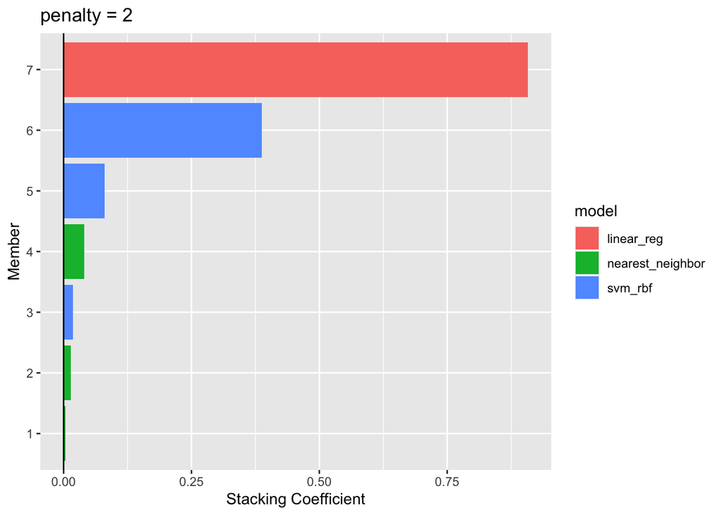

```r
autoplot(blend, type = "weights")
```

Looking at the grpah, there is a nearly 1 to 1 relationship, meaning that the predictions are actually close to the real values.

We also see from the table of rmse ranked that the ensemble model was better than any of its member models, given that rmse was the lowest.

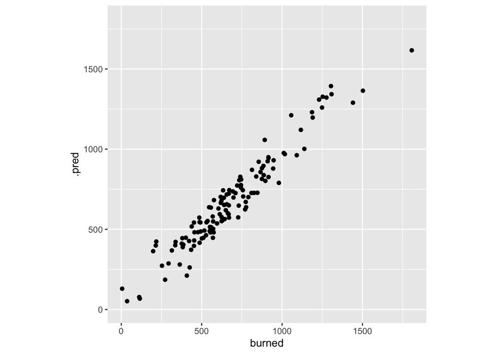

```r
graph
```

```r
rmse_ranked
```

```
## # A tibble: 9 × 4
##   .metric .estimator .estimate member
##   <chr>   <chr>          <dbl> <chr>
## 1 rmse    standard         0   burned
## 2 rmse    standard        81.2 .pred
## 3 rmse    standard        81.3 lin_reg_res_1_1
## 4 rmse    standard       143.  knn_res_1_09
## 5 rmse    standard       143.  knn_res_1_10
## 6 rmse    standard       143.  knn_res_1_11
## 7 rmse    standard       304.  svm_res_1_16
## 8 rmse    standard       286.  svm_res_1_17
## 9 rmse    standard        82.0 svm_res_1_19
```

## Github Repo Link

[Louis Yang](https://github.com/louis20y/L06-louis20y)